# metaheuR: First steps

Borja Calvo, Josu Ceberio, Usue Mori

2017-02-08

The `metaheuR` package is an `R` package being developed for its use in the course Bilaketa Heuristikoak (Search Heuristics) taught at the University of the Basque Country. As so, this package has been designed to help students experiment with the different aspects of the metaheuristics. **It is, by no means, an efficient package** to do actual optimization. If you are looking for a package to solve real problems, better look elsewere :(.

In a very general way, we can define an optimization problem as a problem for which there is a (usually huge) number of solutions that can, somehow, be evaluated; The goal is to find the optimal one among those solutions. There are many types of optimization problems, but this package focuses on those known as *combinatorial optimization problems*.

In any optimization problem we need to define, at least, a couple of elements. The first one is the *solution representation*, i.e., how the real-life solutions can be represented in a computer. The second one is the procedure used to evaluate the quality of a given solution, which is usually materialized in an *objective function*. Depending on the problem, the concept of *optimizing* will be translated to finding the solution that *maximizes* or *minimizes* the objective function. In this package we will assume that the goal is **to minimize the objective function**.

Due to their complexity, many optimization problems cannot be efficiently solved using exact methods. In those cases, heuristic methods are typically used to generate good solutions in a reasonable amount of time. Heuristics are based on intuitions about the problem, but in many cases they can not be easily extrapolated to other problems. This is the reason why metaheuristic algorithms have been proposed. Very informally, we can think of metaheuristics as *templates* that can be used to create heuristic algorithms.

This package includes, so far, some basic meataheuristc algorithms, as well as a number classical optimization problems. The code in the package can be roughly divided into four categories:

- **Optimization problems** - There are a number of functions that can be used to create optimization problems. Each optimization problem consists of a list of functions, such as the evaluation function, required to solve a given problem. At the end of the vignette devoted to optimization problems you will find more information about how these problems have been implemented
- **Metaheuristics** - A set of functions that implement different algorithms to solve optimization problems. These algorithms follow a general implementation and, therefore, rely on the definition of different operators, i.e., functions that perform different operations on a particular form of solution codification
- **Operators and related functions** - As we have said, the implemented algorithms depend on external functions that are able to manipulate solutions. These functions are dependant on the solution representation and/or the problem itself. The package includes some standard functions for certain types of codifications (permutations and vectors)
- **Execution control and visualization** - There are some classes and functions that are used to control the computational resources consumed during the search. Due to its teaching nature, the package also includes a number of functions to plot solutions, the search progress, algorithms behaviour, etc.

In further vignettes we will cover each of these aspects individually, but as a starter, here is an example of use. The first step is to create a problem. In this case, the problem we will solve is a classical *graph coloring problem* where, given a graph, the goal is to assign a color to each node such that any two connected nodes are not assigned the same color; the optimal solution is the one that uses the less number of colors.

In order to create a new instance of the problem we need to provide a graph in `igraph` format. In this example we will randomly create one using the package [`igraph`](http://cran.r-project.org/web/packages/igraph/index.html)

```r
library("metaheuR")
library("igraph")
set.seed(1)
num.nodes <- 25
rnd.graph <- random.graph.game(n=num.nodes, p.or.m=0.15)
```

Now that we have the graph, we can create a new graph coloring problem.

```r
gcp <- graphColoringProblem (graph=rnd.graph)
names(gcp)
```

```
## [1] "evaluate" "valid"    "correct"  "plot"
```

This function creates a list that includes four functions which can be used to evaluate, check, correct and plot solutions. Now we can create an example solution for this problem, which consists in assigning the same color to all the nodes (obviously, this is not a valid solution for the problem unless the graph has no arcs). We can plot this solution using the `plot` function provided by `graphColoringProblem`.

```r
solution <- factor(rep("C1", num.nodes), levels=paste("C", 1:num.nodes, sep=""))
solution
```

```
##  [1] C1 C1 C1 C1 C1 C1 C1 C1 C1 C1 C1 C1 C1 C1 C1 C1 C1 C1 C1 C1 C1 C1 C1
## [24] C1 C1
## 25 Levels: C1 C2 C3 C4 C5 C6 C7 C8 C9 C10 C11 C12 C13 C14 C15 C16 ... C25
```

```r
gcp$valid(solution)
```

```
## [1] FALSE
```

```r
gcp$evaluate(solution)
```

```
## [1] 1
```

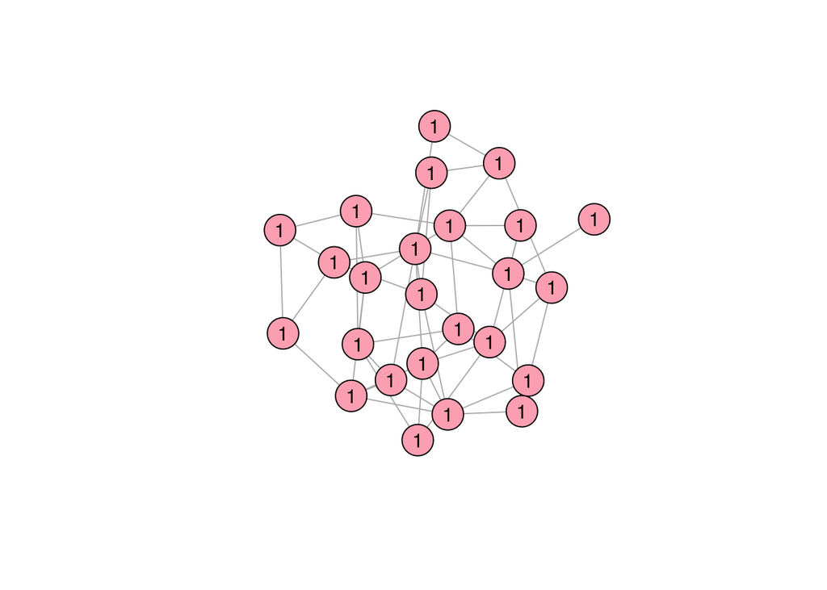

```r
gcp$plot(solution, node.size=20, label.cex=1)
```

The proposed solution only uses 1 color and that is, precisely, it’s evaluation. However, it is not a valid solution. In order to deal with this problem, the `graphColoringProblem` function provides us with a function to correct solutions. It implements a heuristic apprach to turn the solution into a valid one, trying to use as few colors as possible. Applying this function to our proposed solution we obtain a new, valid one.

```r
corrected.solution <- gcp$correct(solution)
corrected.solution
```

```
##  [1] C2 C2 C2 C3 C3 C2 C2 C4 C2 C3 C3 C4 C3 C4 C4 C4 C2 C3 C1 C2 C3 C1 C5
## [24] C1 C1
## 25 Levels: C1 C2 C3 C4 C5 C6 C7 C8 C9 C10 C11 C12 C13 C14 C15 C16 ... C25
```

```r
gcp$valid(corrected.solution)
```

```
## [1] TRUE
```

```r
gcp$evaluate(corrected.solution)
```

```
## [1] 5
```

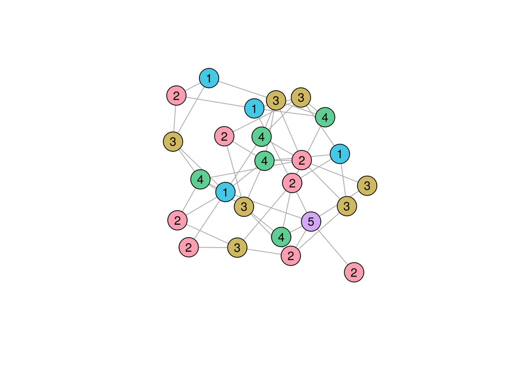

```r
gcp$plot(corrected.solution, node.size=20, label.cex=1)
```

A trivial solution for the *graph coloring problem* is one that assigns a different color to each node.

```r
trivial.solution <- factor(paste("C", 1:num.nodes, sep=""),
                           levels=paste("C", 1:num.nodes, sep=""))
trivial.solution
```

```
##  [1] C1  C2  C3  C4  C5  C6  C7  C8  C9  C10 C11 C12 C13 C14 C15 C16 C17
## [18] C18 C19 C20 C21 C22 C23 C24 C25
## 25 Levels: C1 C2 C3 C4 C5 C6 C7 C8 C9 C10 C11 C12 C13 C14 C15 C16 ... C25
```

```r
gcp$valid(trivial.solution)
```

```
## [1] TRUE
```

```r
gcp$evaluate(trivial.solution)
```

```
## [1] 25
```

We can improve this solution using a basic local search algorithm. In order to do so, we need a neighborhood definition and a procedure to select a solution from the neighborhood. In this case, we restrict the neighborhood to those solutions that are at a Hamming distance of 1. Regarding the selection of the neighbor solution we will use a greedy strategy, i.e., we will always select the best neighbor; These and other aspects of the algorithms will be treated in more detail in further vignettes.

```r
hamm.ngh <- hammingNeighborhood(base=trivial.solution)

bls <- basicLocalSearch(evaluate=gcp$evaluate,
                        non.valid='discard',
                        valid=gcp$valid,
                        initial.solution=trivial.solution,
                        neighborhood=hamm.ngh,
                        selector=greedySelector)
```

The object returned by the algorithm contains information about the search. Among other information (that will also be covered in more detain in further vignettes), we have the best solution found by the algorithm, its evaluation and the progress of the search. The functions `getSolution` and `getEvaluation` can be used to access the first two, and the latter can be visualized using the function `plotProgress`.

```r
getEvaluation(bls)
```

```
## [1] 5
```

```r
getSolution(bls)
```

```
##  [1] C2  C2  C2  C5  C5  C2  C2  C9  C9  C5  C5  C9  C5  C9  C9  C9  C2
## [18] C5  C20 C20 C5  C9  C24 C24 C20
## 25 Levels: C1 C2 C3 C4 C5 C6 C7 C8 C9 C10 C11 C12 C13 C14 C15 C16 ... C25
```

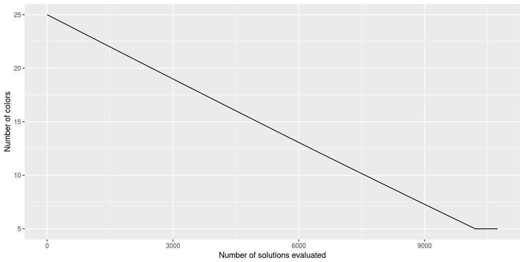

```r
plotProgress(bls) + labs(y="Number of colors",
                         x="Number of solutions evaluated")
```

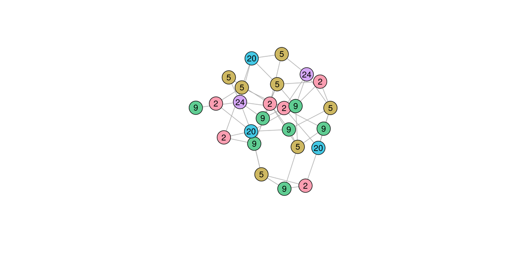

```r
gcp$plot(getSolution(bls), node.size=20, label.cex=1)
```

In further vignettes we will cover, first, the implementation of problems and how neew problems can be incorporated to the package. Then, we will go into more detail about the algorithms currently available. This last vignette will include also some information about how new operators can be implemented in order to make the algorithms available for further solution representations.